# 04 — Design and interpret carbon and alkalinity experiments

**Learning goals:** specify matched experiments; map external inputs; use budget-checked anomalies to explain mechanisms, timing and limits.

**Reading key:** **Key term** = concept to notice. Blue **Question** panels identify student work; purple **Instructor answer** panels appear only in the instructor sheet. Code labels distinguish **Choose and explain**, **Understand and run**, and **Supplied implementation**. This practical is ungraded. Keep your explanations here; no separate submission is required. The coding cheatsheet is optional lookup support; essential syntax is explained locally.

```python
# Supplied implementation: run this support code as provided.
from pathlib import Path
import sys
import numpy as np
import pandas as pd
import matplotlib.pyplot as plt

ROOT = next(p for p in (Path.cwd().resolve(), *Path.cwd().resolve().parents)
            if (p / 'teaching_config.py').is_file())
if str(ROOT) not in sys.path:
    sys.path.insert(0, str(ROOT))

from esbmtk import Signal, Source, Species2Species
from model import initialize_model, postprocess_carbonate_horizons, run_model
from presets import load_boudreau_parameters, make_pump_variant
from reservoir_inputs import reservoir_inventory_rows
from model_inputs import read_model_tables

DATA = ROOT / 'data' / 'Boudreau_2010'
WORKBOOK = DATA / 'model_definition.xlsx'
P = load_boudreau_parameters(WORKBOOK)
input_tables = read_model_tables(WORKBOOK)
STATE = DATA / 'steady_state'
PULSE_FILE = DATA / 'IS92a-scenario.csv'
DIGITIZED = DATA / 'digitized'
REFERENCE_SCALE = 0.877
PULSE_START = 1800.0
REFERENCE_CARBON_PMOL = 335.3560189847107
OAE_TARGET_PMOL = 10.0
OAE_SCALE = REFERENCE_SCALE * OAE_TARGET_PMOL / REFERENCE_CARBON_PMOL
from teaching_audits import audit_complete_model
```

## A1. Reuse the model specification from 03

Your completed schematic is the experiment map. Add only the external carbon or TA arrow; identify the outputs you will examine. The workbook owns the same geometry, box-specific T/S/P, transport and baseline rates. Each case gets an independent parameter copy and the same archived stationary state. Workbook initial concentrations are replaced by that restart.

The supplied `build_complete_case` below returns a fresh, unrun model. After changing a forcing choice, rerun its definition and all subsequent case/run cells. Changes to baseline geometry, chemistry or process rates require a fresh compatible stationary control.

POC/PIC export remains fixed. Weathering, gas exchange and state-dependent dissolution/burial remain active. The atmospheric reservoir is finite. Ocean acidification (OA) here is driven by atmospheric carbon input; idealized ocean alkalinity enhancement (OAE) adds surface TA with no direct carbon input.

Keep these prescribed inputs: OA uses the archived IS92a-shaped forcing (scale 0.877, no terrestrial uptake), while OAE uses the same shape/timing at a different amplitude. Runs last 3800 model years with a one-month maximum step. These choices reproduce a benchmark and test a specified intervention; they are not present-day forecasts.

**Question — specify and predict before running**

Complete the entry-species/receiving-state fields through Exercise 04.2 below and your diagram. State what must match the control. Predict the sign of atm CO2 and surface pH anomalies in OA and OAE; identify a diagnostic whose opposite sign would challenge your prediction. Revisit this prediction in your four final answers.

| Case | External input after year 1800 | Entry species / receiving state | Initial state and baseline |
| --- | --- | --- | --- |
| Control | None | No forcing connection | Archived restart; fixed benchmark parameters |
| OA | About 4025 Gt C | Your diagram and code choice | Same as control |
| OAE | 10 Pmol TA equivalents | Your diagram and code choice | Same as control |

The whole-run forcing includes a small pre-1800 tail. The supplied audit reports both intervals. The amounts and units differ, so raw OA/OAE curves do not compare equal-strength interventions.

**Instructor answer**

OA adds carbon to atmospheric CO2; OAE adds TA to low-latitude surface TA. Match geometry, chemistry, baseline rates, clock and restart with the control. Expected early OA anomalies are positive atm CO2 and negative surface pH; OAE is expected to give negative atm CO2 and positive surface pH. Opposite sustained anomalies in those diagnostics would require checking the choices and revisiting the explanation.

**Optional reference — inspect the shared workbook again**

The following function displays input records only if you call it. The core uses the specification you already inspected in 03. Numerical baseline inputs stay in `model_definition.xlsx`.

```python
# Supplied implementation: optional lookup, not another required table-reading task.
def show_input_reference():
    display(pd.DataFrame(input_tables['OceanReservoirs']).set_index('Box ID'))
    display(pd.DataFrame(input_tables['Atmosphere']).set_index('Box ID'))
    display(pd.DataFrame(input_tables['TransportConnections']).sort_values('Order'))
    display(pd.DataFrame(input_tables['GasExchangeConnections']).sort_values('Order'))
    display(pd.DataFrame(input_tables['ProcessParameters']).set_index('Parameter'))
# To inspect the tables again, run show_input_reference().
```

## A2. Exercise 04.1: specify the two forcing inventories

Retain the benchmark OA forcing: the archived IS92a-shaped input adds about 4025 Gt C after model year 1800 (12 g C/mol). OAE uses the same shape and timing but adds 10 Pmol TA equivalents over that interval. These are an OA benchmark and an idealized OAE experiment, not equal-amplitude interventions.

**Question — specify forcing inventories**

Assign `oa_target_mol` and `oae_target_mol` in mol C and mol TA equivalents. One Gt is 10^15 g; one Pmol is 10^15 mol. The supplied scaling code retains the archived pulse, including its small pre-1800 tail. Inventory reports show both the post-1800 benchmark amount and the full input used in the model budget.

```python
# Choose and explain: complete marked choices; surrounding machinery is supplied.
# Exercise 04.1: convert the prescribed amounts to the model's mol units.
# BEGIN SOLUTION
oa_target_mol = 4025.0 * 1e15 / 12.0
oae_target_mol = 10.0 * 1e15
# END SOLUTION
# Supplied conversion from inventory to the archived signal's scale factor.
# Keep its exact reference normalization; 4025 Gt is a rounded comparison target.
np.testing.assert_allclose(oa_target_mol / 1e15, REFERENCE_CARBON_PMOL, rtol=1e-3)
oae_scale = REFERENCE_SCALE * oae_target_mol / (REFERENCE_CARBON_PMOL * 1e15)
```

## A3. Exercise 04.2: map the external arrows

**Question — implement the experiment specification**

Inside each branch, assign `forcing_species` and `forcing_target` from your diagram. Choose from the model's CO2 and TA species and its atmospheric CO2 or low-latitude surface TA state. No pH is imposed; it is calculated from the evolving state.

`Source` represents material outside the boundary. `Signal` supplies a time-dependent flux; the native connection attaches it to the chosen state. The control has no such connection. Constructor syntax, waveform scaling and the numerical audit are supplied.

```python
# Choose and explain: complete marked choices; surrounding machinery is supplied.
def build_complete_case(forcing=None):
    # Supplied model and stationary restart; pumps remain fixed.
    params = make_pump_variant(
        base=P, solubility_strength=1.0, soft_tissue_strength=1.0,
        carbonate_strength=1.0, soft_tissue_feedback=False, carbonate_feedback=False,
    )
    model = initialize_model(params, stop='3800 yr', max_timestep='1 month')
    model.read_state(directory=str(STATE))
    if forcing is None:
        return model
    # Exercise 04.2: set the species and receiving state in both cases.
    if forcing == 'OA':
        # BEGIN SOLUTION
        forcing_species, forcing_target = model.CO2, model.CO2_At
        # END SOLUTION
    elif forcing == 'OAE':
        # BEGIN SOLUTION
        forcing_species, forcing_target = model.TA, model.L_b.TA
        # END SOLUTION
    else:
        raise ValueError(forcing)
    scale = {'OA': REFERENCE_SCALE, 'OAE': oae_scale}[forcing]
    signal = Signal(name='external_input', species=forcing_species, register=model,
                    filename=str(PULSE_FILE), scale=scale)
    source = Source(name='external_source', species=forcing_species)
    connection = Species2Species(source=source, sink=forcing_target,
                                rate='0 mol/yr', signal=signal, id='external_input')
    model.teaching_signal = signal
    model.teaching_connection = connection
    # Preserve the exact solver input for the supplied continuous budget audit.
    model.teaching_signal_time = model.time.copy()
    model.teaching_signal_flux = signal.m.copy()
    if forcing == 'OA':
        model.carbon_signal = signal
    else:
        model.alkalinity_signal = signal
    return model

fixed_cases = {label: build_complete_case(None if label == 'control' else label)
               for label in ('control', 'OA', 'OAE')}
assert fixed_cases['OA'].teaching_connection.sink is fixed_cases['OA'].CO2_At
assert fixed_cases['OAE'].teaching_connection.sink is fixed_cases['OAE'].L_b.TA
display(pd.DataFrame(reservoir_inventory_rows(fixed_cases['control'])).set_index('Box'))
```

[output not shown]

[output not shown]

[output not shown]

| Box | Density (kg/m3) | Water mass (kg) | Initial carbon (mol) | Initial TA (mol eq) |
| --- | --- | --- | --- | --- |
| H_b | 1028.798771 | 1.810686e+19 | 3.896917e+16 | 4.252578e+16 |
| L_b | 1024.575722 | 2.920041e+19 | 5.667813e+16 | 6.664200e+16 |
| D_b | 1038.983451 | 1.340289e+21 | 3.076045e+18 | 3.221934e+18 |

## B1. Verify inputs and the boundary budget

In 03, internal water, gas and POC transfers cancel when summing inventories. Including external carbon $I_C(t)$ and TA $I_A(t)$ gives $$\frac{dC_{atm+ocn}}{dt}=I_C(t)+W_C-B_{net}(t),\qquad \frac{dA_{ocn}}{dt}=I_A(t)+W_A-2B_{net}(t).$$ These are boundary-aware budgets, not constant-inventory tests. Net burial may change in response to forcing. Pure-TA OAE sets $I_C=0$; distinguish direct external carbon input from internal air–sea redistribution.

The supplied code checks forcing units and integrated amounts before integration, then evaluates the same carbonate flux law used by the solver to audit all saved times. Small tolerance also covers numerical quadrature of the diagnostic flux history. Inspect budget errors before interpreting responses.

```python
# Understand and run: trace this supplied step and interpret its evidence.
from teaching_audits import integrate_forcing_history

forcing_rows = {}
for label, target in (('OA', oa_target_mol), ('OAE', oae_target_mol)):
    case = fixed_cases[label]
    time, flux = case.teaching_signal_time, case.teaching_signal_flux
    total = integrate_forcing_history(time, flux, time[-1])
    after_start = total - integrate_forcing_history(time, flux, PULSE_START)
    np.testing.assert_allclose(after_start, target, rtol=1e-3)
    forcing_rows[label] = {'post-1800 input (Pmol C or TA eq)': after_start / 1e15,
                           'whole-run input (Pmol C or TA eq)': total / 1e15}
display(pd.DataFrame(forcing_rows).T)

for label, case in fixed_cases.items():
    print('Running', label)
    run_model(case)
    postprocess_carbonate_horizons(case)
display(pd.DataFrame({label: audit_complete_model(case, label)
                      for label, case in fixed_cases.items()}).T)
```

|  | post-1800 input (Pmol C or TA eq) | whole-run input (Pmol C or TA eq) |
| --- | --- | --- |
| OA | 335.357579 | 340.172309 |
| OAE | 10.000047 | 10.143617 |

```
Running control
```

```
status=0
message=The solver successfully reached the end of the integration interval.


 Execution took 13.28 CPU seconds, wall time = 13.40 seconds

Running OA
```

```
status=0
message=The solver successfully reached the end of the integration interval.


 Execution took 17.08 CPU seconds, wall time = 17.45 seconds

Running OAE
```

```
status=0
message=The solver successfully reached the end of the integration interval.


 Execution took 14.94 CPU seconds, wall time = 14.98 seconds
```

|  | max carbon error / initial stock | max TA error / initial stock | external input (Pmol C or TA eq) |
| --- | --- | --- | --- |
| control | 1.084733e-08 | 2.096911e-08 | 0.000000 |
| OA | 8.335061e-06 | 1.108447e-06 | 340.172309 |
| OAE | 7.444546e-08 | 2.116669e-07 | 10.143617 |

## B2. Start with matched responses

For each quantity use $$\Delta Y(t)=Y_{forced}(t)-Y_{control}(t).$$ This compares the imposed forcing against the same baseline evolution, including control drift. It isolates the response within this deterministic model; subtraction does not eliminate numerical errors or validate omitted processes.

Read four diagnostic groups: atm CO2, surface pH, deep DIC and dissolution/net burial. Compare signs and timing against your initial prediction. Read units and scales: these unequal forcing amounts do not establish relative intervention efficiency.

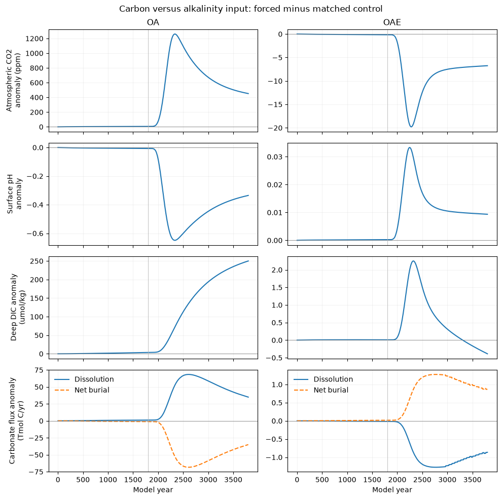

```python
# Understand and run: trace this supplied step and interpret its evidence.
from teaching_plots import plot_matched_responses
plot_matched_responses(fixed_cases, pulse_start=PULSE_START)
plt.show()
```

## B3. Use the complete figures for pathways and sediment memory

The supplied plots below use the same integrated cases. Solid curves are the model; OA's dotted curves reproduce the archived published comparison. That overlay checks reproduction, while matched anomalies address the forcing response.

| Panel | Diagnostic | Use |
| --- | --- | --- |
| g | External carbon or TA input | Prescribed cause, with distinct units |
| f / c | atm CO2 / pH | Check your predicted atmosphere/surface response |
| a / b / d | DIC / TA / gas exchange | Trace transfer and redistribution |
| e / h | Horizons / dissolution and burial | Examine deep chemistry and sediment history |

The **saturation horizon** has calcite saturation = 1; the **compensation depth** concerns complete dissolution of modern rain; the **snowline** is the boundary of existing reactive sediment. The first two respond to current chemistry/rain, while snowline motion retains history. Plot e uses negative depth (elevation), so upward means shallower.

Consult e/h for the sediment answer and the OA overlay for reproduction. There is no extra panel-by-panel report. The final plotted time need not be a new equilibrium.

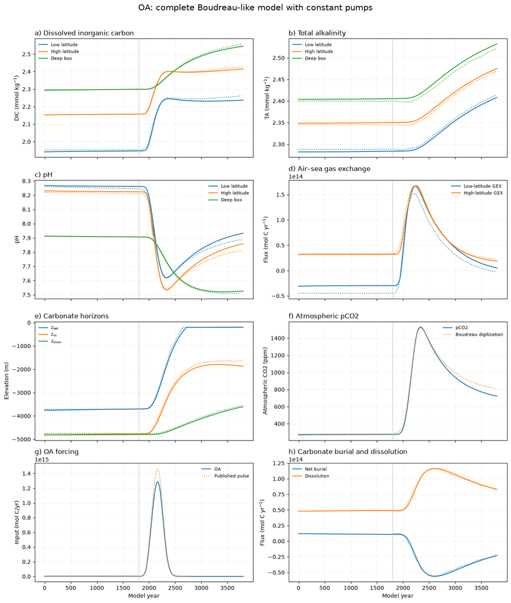

```python
# Understand and run: trace this supplied step and interpret its evidence.
from teaching_plots import plot_figure4
plot_figure4(fixed_cases['OA'], 'OA', reference=True,
             digitized=DIGITIZED, pulse_start=PULSE_START)
plt.show()
```

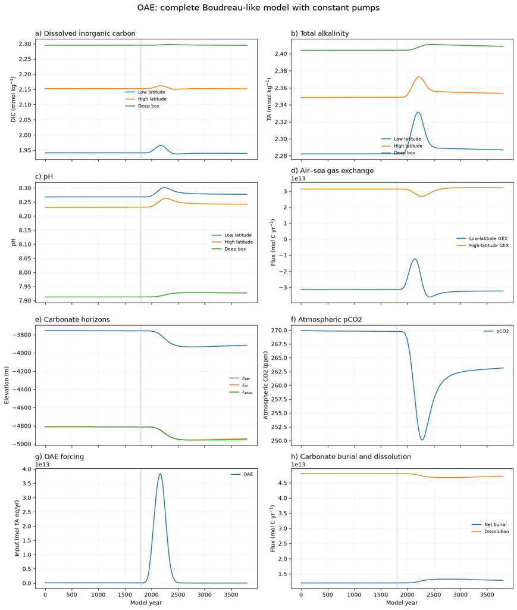

```python
# Understand and run: trace this supplied step and interpret its evidence.
plot_figure4(fixed_cases['OAE'], 'OAE', pulse_start=PULSE_START)
plt.show()
```

## C. Explain the experiment in four short answers

**Question — evidence, mechanisms and next test**

1. **Design and evidence:** identify the entry species/state in each case and what matches the control. Use the atm/surface anomalies to assess your prediction. Why can comparison with the initial state alone be misleading if the control drifts?
2. **Mechanism and budget:** explain how TA input changes atmospheric CO2 without directly supplying carbon. Trace the internal transfer and use the boundary budget. Why are these experiments neither opposite nor equal-strength inputs?
3. **Time and process:** identify a surface/deep response lag and use e/h to explain the linked 1 DIC : 2 TA transfers and sediment memory. What evidence would you need before claiming equilibration?
4. **Claims and next test:** distinguish benchmark reproduction from a conditional prediction. Choose one fixed assumption and propose one changed input, matched control and diagnostic for a follow-up test. One or two sentences are enough; do not run a fourth case in the core.

**Instructor answer**

1. OA enters `CO2_At` as CO2 and OAE enters `L_b.TA` as TA. Geometry, chemistry, rates, clock and restart match the control. The anomalies show positive atm CO2/negative surface pH for OA and the opposite initial tendency for OAE. Forced-minus-initial includes baseline evolution; forced-minus-control removes that shared drift.
2. TA changes carbonate partitioning and aqueous CO2, inducing internal atmospheric-to-ocean transfer. No carbon enters directly through the TA connection. The total active carbon can still differ from control because net burial responds. The cases differ in species, amount and nonlinear chemical/sediment response; opposite signs do not imply cancellation or comparable efficiency.
3. Surface chemistry responds before the transported deep signal. Carbonate dissolution returns 1 DIC and 2 TA, while net burial removes them. OA tends to increase dissolution/reduce burial; OAE tends to oppose this, modifying the forcing response. Chemical horizons respond to current conditions while the snowline can lag. Small sustained tendencies and balanced fluxes over a sufficiently long interval would support stationarity; the last plotted point alone does not.
4. The OA overlay checks reproduction of a published model, not independent observational validation. The forcing response is conditional on assumptions. For example, compare two temporal shapes with equal integrated TA using the same unforced control and measure the atm CO2 anomaly at a stated time. Or test a state-dependent export hypothesis against a fixed-export control, first preparing compatible stationary baselines and retaining PIC stoichiometry.

**You have completed 04.** Keep the forcing choices, checked budgets and four explanations in this notebook. The independent-model starter and attribution/feedback extension are optional work outside the core.